# Predicting Logerror

# #3 Time Sold Cluster

'transactiondate'

```python
#Standard Scaler Clusters
x_train_ss.cluster_sold.value_counts()
```

```
2    11567
1     9063
0     8424
Name: cluster_sold, dtype: int64
```

### Same for robust scaler

```python
x_trrs_model = pd.get_dummies(x_trrs_model, columns = ['cluster_location', 'cluster_sold'], dummy_na=False, drop_first= False)
x_trrs_model.head()
```

|  | bed_x_bath | sqft | lot_sqft | yearbuilt | cluster_location_0 | cluster_location_1 | cluster_location_2 | cluster_sold_0 | cluster_sold_1 | cluster_sold_2 |
| --- | --- | --- | --- | --- | --- | --- | --- | --- | --- | --- |
| 14166 | 0.4 | 0.064922 | -0.562859 | 0.206897 | 0 | 1 | 0 | 1 | 0 | 0 |
| 34345 | -0.8 | -0.606589 | -0.249573 | -0.344828 | 0 | 1 | 0 | 0 | 0 | 1 |
| 51345 | 0.4 | 0.117248 | 0.422067 | 0.000000 | 0 | 1 | 0 | 0 | 1 | 0 |
| 5495 | 0.0 | -0.211240 | -0.400000 | 0.172414 | 0 | 1 | 0 | 1 | 0 | 0 |
| 35164 | 0.0 | 0.031008 | 0.206993 | 0.517241 | 0 | 1 | 0 | 0 | 0 | 1 |

```python
# The smallest cluster size is 2_443
# the train set is 29_000
# i don't think the curse of dimensionality will be a limiting factor in model accuracy
```

# Baseline

because the target variable is both +/- numbers, i will be taking the abs value to determine baseline mean and baseline realtionships

baseline is evaluated on RMSE of actual vs mean

# Number to beat is

0.16652630703887997

# Models

1. GLM (power=0, alpha=0)
2. Polynomial Regression (deg =2)
3. LassoLars (alpha = 1.0)
4. Linear Regression

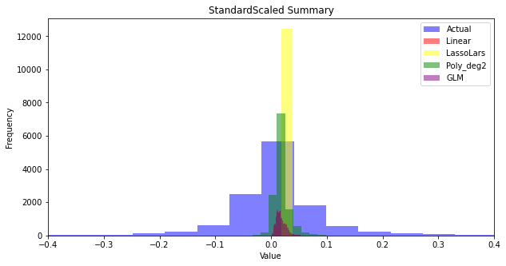

```python
#Distribution of my models' predictions
plt.figure(figsize=(10,5))

plt.hist(y_validate_ss, bins = 100, color='blue', alpha=0.5, label='Actual')
plt.hist(y_valslm, bins = 50, color='red', alpha=0.5, label='Linear')
plt.hist(y_val_s_lars, bins = 50, color='yellow', alpha=0.5, label='LassoLars')
plt.hist(y_valss_deg1, bins = 50, color='green', alpha=0.5, label='Poly_deg2')
plt.hist(y_val_s_glm0, bins = 50, color='purple', alpha=0.5, label='GLM')

plt.xlim(-.4,.4)
plt.xlabel('Value')
plt.ylabel('Frequency')
plt.title('StandardScaled Summary')
plt.legend()
```

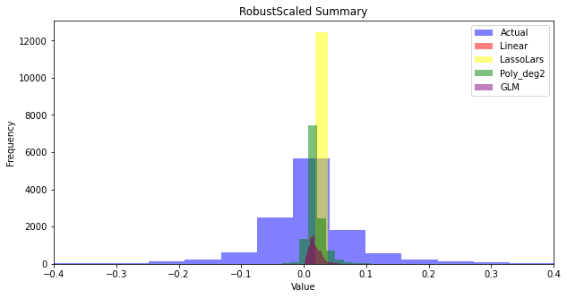

```python
#Distribution of my models' predictions
plt.figure(figsize=(10,5))

plt.hist(y_validate_rs, bins = 100, color='blue', alpha=0.5, label='Actual')
plt.hist(y_valrslm, bins = 50, color='red', alpha=0.5, label='Linear')
plt.hist(y_val_rs_lars, bins = 50, color='yellow', alpha=0.5, label='LassoLars')
plt.hist(y_valrs_deg1, bins = 50, color='green', alpha=0.5, label='Poly_deg2')
plt.hist(y_val_rs_glm0, bins = 50, color='purple', alpha=0.5, label='GLM')

plt.xlim(-.4,.4)
plt.xlabel('Value')
plt.ylabel('Frequency')
plt.title('RobustScaled Summary')
plt.legend()
```

```python
rmse_sumT.sort_values(by = 0)
```

|  | 0 |
| --- | --- |
| poly2_val_ss | 0.164389 |
| poly2_val_rs | 0.164403 |
| lassolars_val_rs | 0.164564 |
| lassolars_val_ss | 0.164564 |
| linreg_val_ss | 0.164597 |
| linreg_val_rs | 0.164597 |
| glm0_val_rs | 0.164601 |
| glm0_val_ss | 0.164605 |
| baseline | 0.166526 |
| poly2_tr_rs | 0.174559 |
| poly2_tr_ss | 0.174561 |
| linreg_tr_rs | 0.175031 |
| linreg_tr_ss | 0.175042 |
| glm0_tr_rs | 0.175044 |
| glm0_tr_ss | 0.175048 |
| lassolars_tr_ss | 0.175098 |
| lassolars_tr_rs | 0.175098 |

# Polynomial Deg 2 with Standard or Robust Scaling is the best

Baseline rmse: 0.166526 \ Test rmse: 0.162714

# 2.29% increase in accuracy!!

# Conclusion

- Polynomial Regression of the Second Order gave the best results
- Model gives a 2.29% increase in accuracy

# Future Work

- Continue analyzing independent variables to find a stronger correlation with dependent variable
- If I had more time I would run models with different hyperparameters to verify I had the best model available
- I would like to split the data based on land (0 bed/bath), home (1 bath, 1-5 bed), mansion (>5 bed) and run models specific to each